# Assignment 1: Estimating CDF and PDF

Sabah Khan

Due: February 3rd, 2026

#### **Question 1**

##### a) Writing an R Function for ECDF and validating using R’s ecdf function

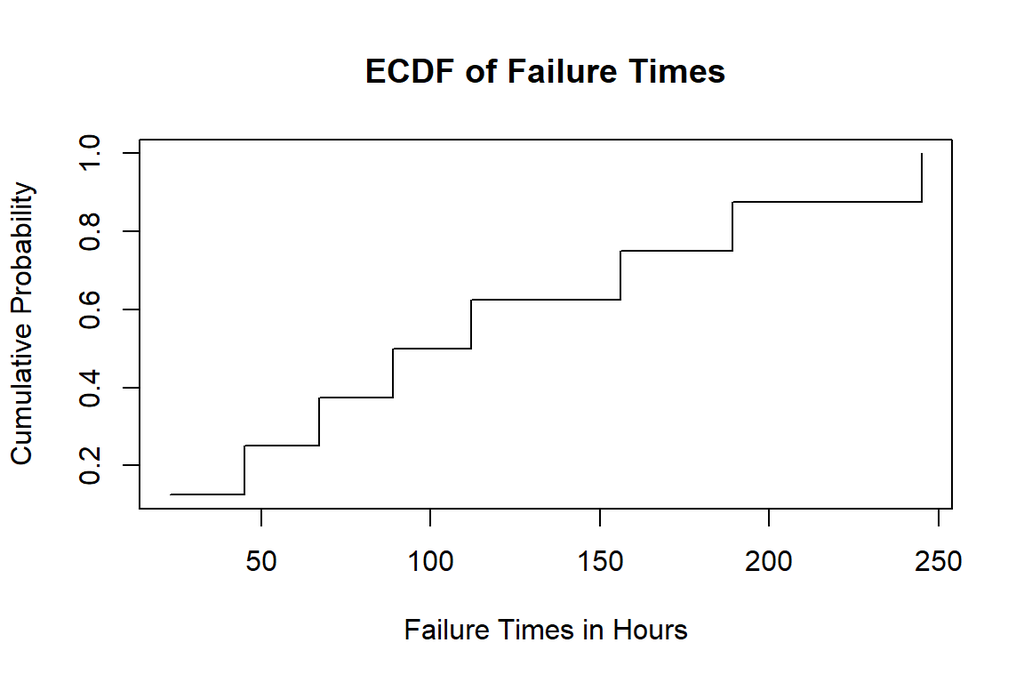

```
## Empirical CDF
## Call: ecdf(times)
##  x[1:8] =     23,     45,     67,  ...,    189,    245
```

##### The ECDF seems to have been set up correctly when comparing the steps in the graph to the numerical values in the ECDF vector for numerical values.

##### b) A colleague claims that the probability of failure before 100 hours is 0.5 based on these data. Do you agree? Explain your reasoning using the empirical cumulative distribution function (ECDF).

##### I agree with my colleague. When looking at the numerical values in the vector containing failure times, we see values 23, 45, 67, 89, 112, 156, 189, and 245. Of these values, 4 are below 100, and 4 are above 100, representing a 50% chance, or 0.5 probability of failure before 100 hours and also a 0.5 probability of failure above 100 hours.

#### **Question 2**

##### a) Histogram of given data with 3 equally spaced bins:

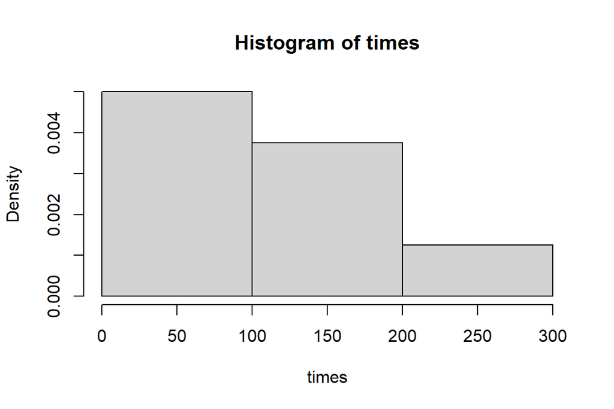

##### b) Writing an R function that computes kernel density estimates using a Gaussian kernel with h=2 and Validating against R’s built-in density() function:

```
##
## Call:
##  density.default(x = times, bw = 2, adjust = 1, kernel = c("gaussian"),     weights = NULL, window = kernel, width = width, give.Rkern = FALSE,     subdensity = FALSE, warnWbw = var(weights) > 0, n = 8, cut = 3,     ext = 4, old.coords = FALSE, na.rm = FALSE)
##
## Data: times (8 obs.);    Bandwidth 'bw' = 2
##
##        x               y
##  Min.   : 17.0   Min.   :0.0000000
##  1st Qu.: 75.5   1st Qu.:0.0003099
##  Median :134.0   Median :0.0007522
##  Mean   :134.0   Mean   :0.0006529
##  3rd Qu.:192.5   3rd Qu.:0.0008547
##  Max.   :251.0   Max.   :0.0013232
```

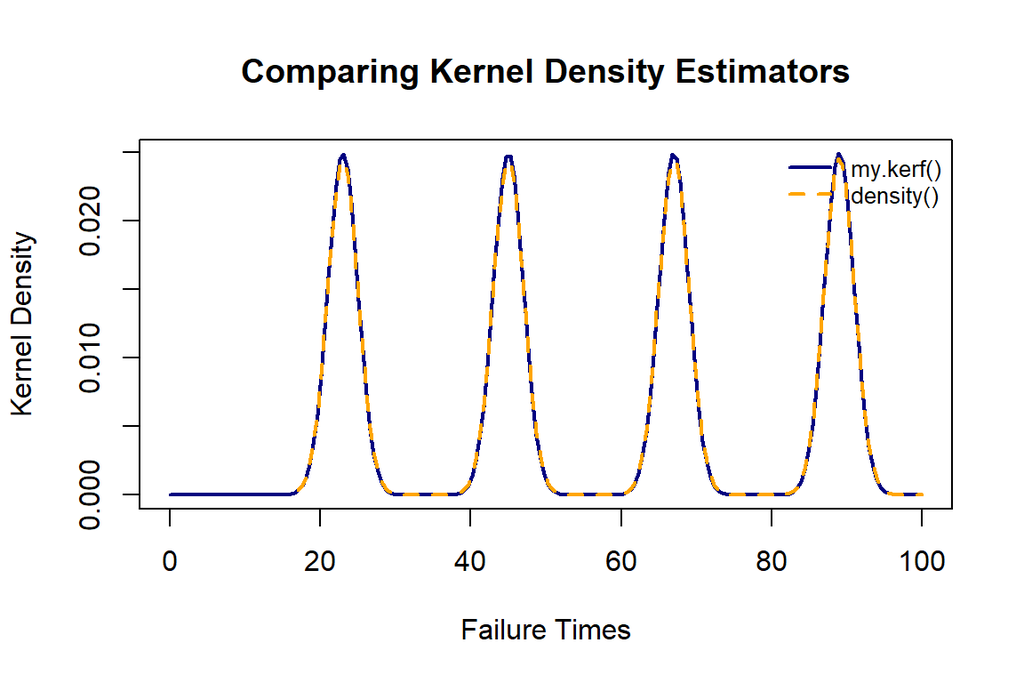

##### My kernel density estimator function and R’s built in density estimator function are practically overlayed on top of one another, thereby validating my kernel density estimator function.

##### c) Writing an R function that computes kernel density estimates using an Epanechnikov kernel with h=2 and Validating against R’s built-in density() function:

```
##
## Call:
##  density.default(x = times, bw = 2, adjust = 1, kernel = c("epanechnikov"),     weights = NULL, window = kernel, width = width, give.Rkern = FALSE,     subdensity = FALSE, warnWbw = var(weights) > 0, n = 8, cut = 3,     ext = 4, old.coords = FALSE, na.rm = FALSE)
##
## Data: times (8 obs.);    Bandwidth 'bw' = 2
##
##        x               y
##  Min.   : 17.0   Min.   :0.000e+00
##  1st Qu.: 75.5   1st Qu.:0.000e+00
##  Median :134.0   Median :0.000e+00
##  Mean   :134.0   Mean   :6.676e-06
##  3rd Qu.:192.5   3rd Qu.:6.163e-07
##  Max.   :251.0   Max.   :5.094e-05
```

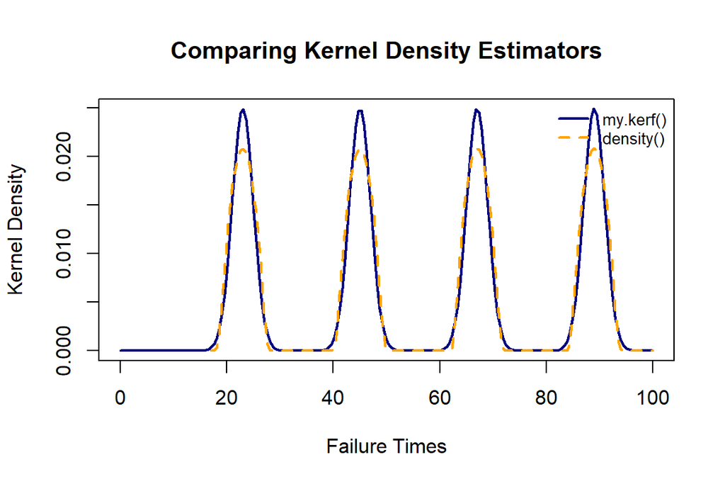

##### We can see that choosing Gaussian kernel is favorable in terms of comparing my density estimator function with R’s build in density estimator function. The Epanechnikov kernel results in a slight density difference between my estimator and R’s estimator.

##### d) Let’s see what happens when we select h=1.5 versus h=2.5 for both kernel estimators.

##### Gaussian Density Estimator with h=1.5:

```
##
## Call:
##  density.default(x = times, bw = 1.5, adjust = 1, kernel = c("gaussian"),     weights = NULL, window = kernel, width = width, give.Rkern = FALSE,     subdensity = FALSE, warnWbw = var(weights) > 0, n = 8, cut = 3,     ext = 4, old.coords = FALSE, na.rm = FALSE)
##
## Data: times (8 obs.);    Bandwidth 'bw' = 1.5
##
##        x                y
##  Min.   : 18.50   Min.   :0.000e+00
##  1st Qu.: 76.25   1st Qu.:3.747e-05
##  Median :134.00   Median :5.077e-05
##  Mean   :134.00   Mean   :1.758e-04
##  3rd Qu.:191.75   3rd Qu.:4.122e-04
##  Max.   :249.50   Max.   :4.279e-04
```

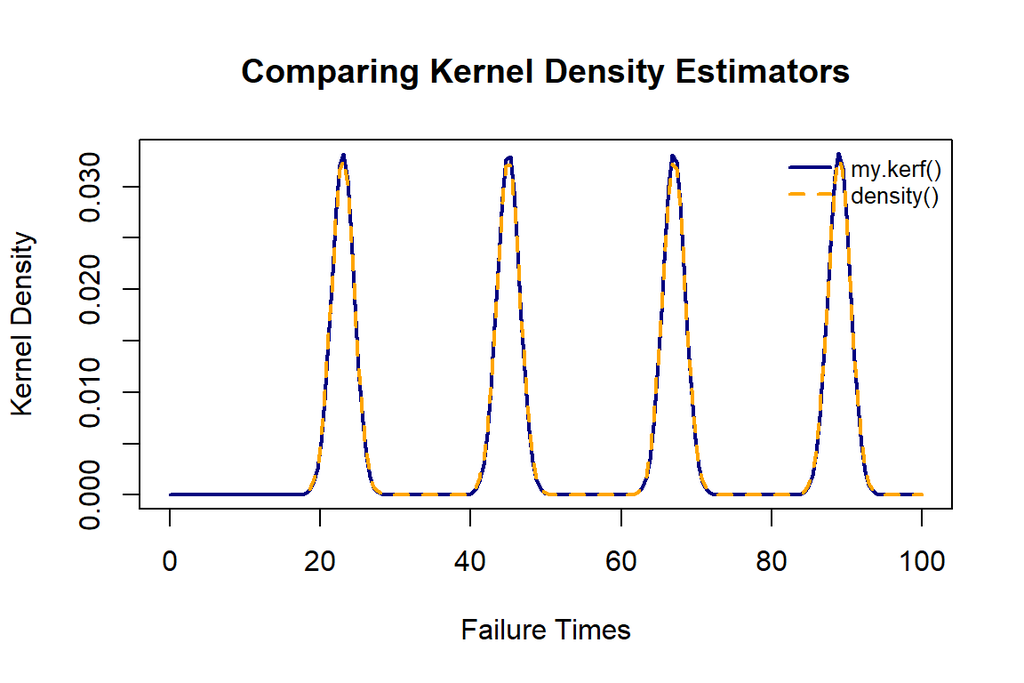

##### Gaussian Density Estimator with h=2.5:

```
##
## Call:
##  density.default(x = times, bw = 2.5, adjust = 1, kernel = c("gaussian"),     weights = NULL, window = kernel, width = width, give.Rkern = FALSE,     subdensity = FALSE, warnWbw = var(weights) > 0, n = 8, cut = 3,     ext = 4, old.coords = FALSE, na.rm = FALSE)
##
## Data: times (8 obs.);    Bandwidth 'bw' = 2.5
##
##        x                y
##  Min.   : 15.50   Min.   :0.0000000
##  1st Qu.: 74.75   1st Qu.:0.0002313
##  Median :134.00   Median :0.0020013
##  Mean   :134.00   Mean   :0.0020486
##  3rd Qu.:193.25   3rd Qu.:0.0030598
##  Max.   :252.50   Max.   :0.0048834
```

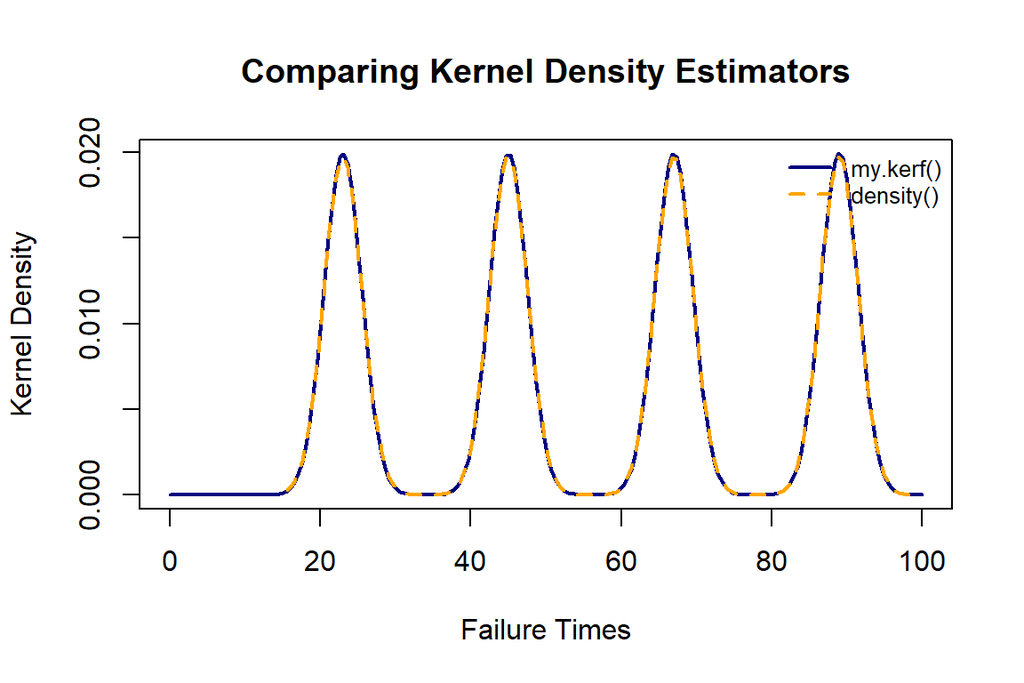

##### Epanechnikov Density Estimator with h=1.5:

```
##
## Call:
##  density.default(x = times, bw = 1.5, adjust = 1, kernel = c("epanechnikov"),     weights = NULL, window = kernel, width = width, give.Rkern = FALSE,     subdensity = FALSE, warnWbw = var(weights) > 0, n = 8, cut = 3,     ext = 4, old.coords = FALSE, na.rm = FALSE)
##
## Data: times (8 obs.);    Bandwidth 'bw' = 1.5
##
##        x                y
##  Min.   : 18.50   Min.   :0.000e+00
##  1st Qu.: 76.25   1st Qu.:0.000e+00
##  Median :134.00   Median :5.114e-20
##  Mean   :134.00   Mean   :8.236e-19
##  3rd Qu.:191.75   3rd Qu.:1.170e-18
##  Max.   :249.50   Max.   :3.146e-18
```

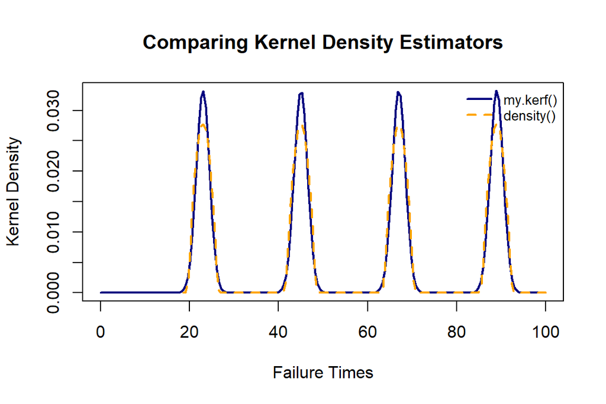

##### Epanechnikov Density Estimator with h=2.5:

```
##
## Call:
##  density.default(x = times, bw = 2.5, adjust = 1, kernel = c("epanechnikov"),     weights = NULL, window = kernel, width = width, give.Rkern = FALSE,     subdensity = FALSE, warnWbw = var(weights) > 0, n = 8, cut = 3,     ext = 4, old.coords = FALSE, na.rm = FALSE)
##
## Data: times (8 obs.);    Bandwidth 'bw' = 2.5
##
##        x                y
##  Min.   : 15.50   Min.   :0.000000
##  1st Qu.: 74.75   1st Qu.:0.000000
##  Median :134.00   Median :0.001550
##  Mean   :134.00   Mean   :0.002468
##  3rd Qu.:193.25   3rd Qu.:0.003825
##  Max.   :252.50   Max.   :0.007189
```

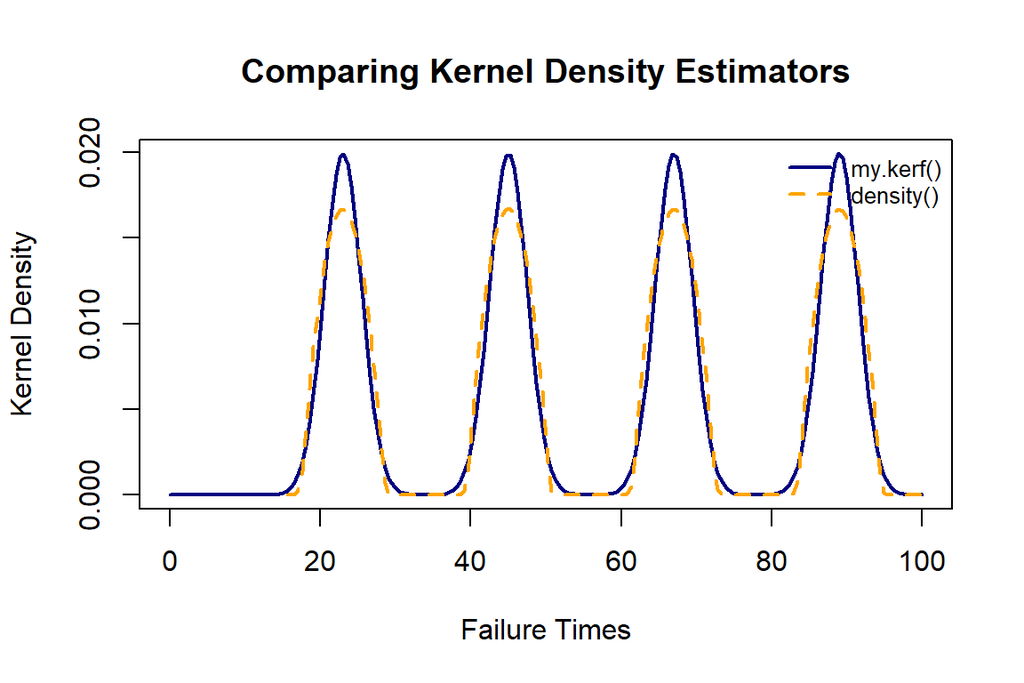